# Find Suitable Locations for a New Campsite in Yosemite

In this Notebook we’ll look for suitable places for new campsites in Yosemite that meet the following criteria:

- within 100m of an existing trail
- slope < 10%
- within 100m of a stream

## Setup

Load the packages we’ll need and set tmap mode to ‘plot’:

```r
library(sf)
library(raster)
library(tmap)
tmap_mode("plot")
```

Load `dplyr` and set name conflict preferences:

```r
library(dplyr)

## Load the conflicted package
library(conflicted)

# Set conflict preferences
conflict_prefer("filter", "dplyr", quiet = TRUE)
conflict_prefer("count", "dplyr", quiet = TRUE)
conflict_prefer("select", "dplyr", quiet = TRUE)
conflict_prefer("arrange", "dplyr", quiet = TRUE)
```

## Import Layers for Yosemite National Park

For this analysis we’ll need the park boundary, the trails network and a DEM (elevation) of the park (from which we can derive slope).

Begin by importing the vector layers:

```r
## Import the park boundary
bnd_fn <- "./data/yose_boundary.shp"
file.exists(bnd_fn)
```

```
[1] TRUE
```

```r
yose_bnd_ll <- st_read(bnd_fn)
## Import the trails
trails_gdb_fn <- "./data/yose_trails.gdb"
file.exists(trails_gdb_fn)
```

```
[1] TRUE
```

```r
yose_trails <- st_read(trails_gdb_fn, layer="Trails")
## Import the rivers and streams
hydro_gdb_fn <- "./data/yose_hydrology.gdb"
file.exists(hydro_gdb_fn)
```

```
[1] TRUE
```

```r
yose_streams <- st_read(hydro_gdb_fn, layer="Rivers")
```

## Project Everything to UTM

Next, we’ll project everything to UTM 11N (EPSG 32611). We need to do this because two of our siting criteria involve distance:

```r
epsg_utm11n_wgs84 <- 32611

yose_bnd_utm <- st_transform(yose_bnd_ll, epsg_utm11n_wgs84)

yose_trails_utm <- st_transform(yose_trails, epsg_utm11n_wgs84)

yose_streams_utm <- st_transform(yose_streams, epsg_utm11n_wgs84)
```

Plot them to verify it worked:

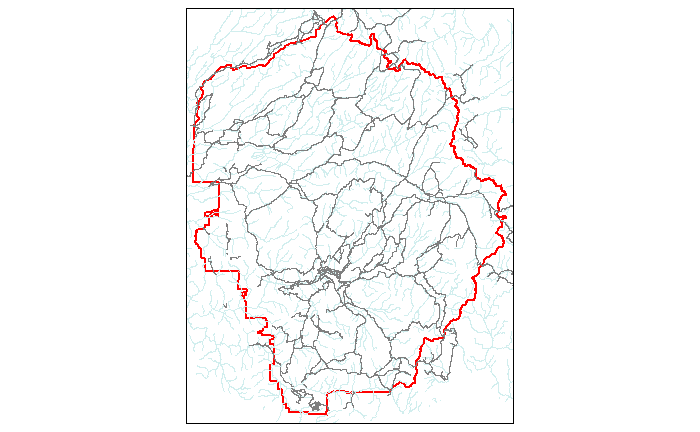

```r
tm_shape(yose_bnd_utm) +
  tm_borders(col = "red", lwd = 2) +
tm_shape(yose_streams_utm) +
  tm_lines("lightcyan2") +
tm_shape(yose_trails_utm) +
  tm_lines("gray50")
```

## Import the DEM

We have elevation data in the form of a tile of SRTM data.

```r
srtm1305_fn <- "./data/srtm_13_05.tif"
file.exists(srtm1305_fn)
```

```
[1] TRUE
```

```r
srtm1305_rst <- raster(srtm1305_fn)
srtm1305_rst
```

```
class      : RasterLayer
dimensions : 6001, 6001, 36012001  (nrow, ncol, ncell)
resolution : 0.0008333333, 0.0008333333  (x, y)
extent     : -120.0004, -114.9996, 34.99958, 40.00042  (xmin, xmax, ymin, ymax)
crs        : +proj=longlat +datum=WGS84 +no_defs
source     : D:/Workshops/R-Spatial/rspatial_mod/outputs/rspatial_data/data/srtm_13_05.tif
names      : srtm_13_05
values     : -32768, 32767  (min, max)
```

## Crop the DEM to the Park Boundary

Note the SRTM data is in geographic coordinates. To see how big it is we’ll overlay the park boundary on it:

```
stars object downsampled to 1000 by 1000 cells. See tm_shape manual (argument raster.downsample)
```

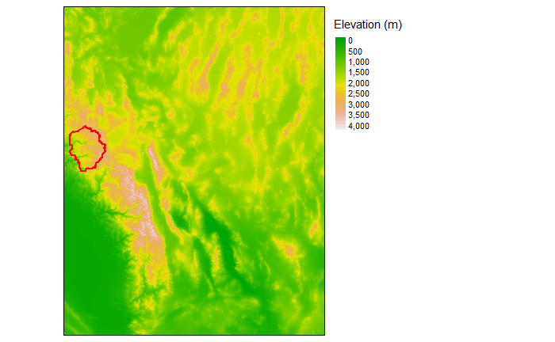

```r
tm_shape(srtm1305_rst) +
  tm_raster(title = "Elevation (m)", style = "cont", n = 15, palette = terrain.colors(256)) +
tm_shape(yose_bnd_ll) +
  tm_borders(col = "red", lwd = 2) +
tm_legend(outside = TRUE)
```

We can crop the large DEM to the park boundary using `crop()`. Remember that the raster and the layer for the crop area need to be in the same CRS:

```r
yose_dem_rst_ll <- raster::crop(srtm1305_rst, yose_bnd_ll)
yose_dem_rst_ll
```

```
class      : RasterLayer
dimensions : 829, 828, 686412  (nrow, ncol, ncell)
resolution : 0.0008333333, 0.0008333333  (x, y)
extent     : -119.8863, -119.1963, 37.49458, 38.18542  (xmin, xmax, ymin, ymax)
crs        : +proj=longlat +datum=WGS84 +no_defs
source     : memory
names      : srtm_13_05
values     : 436, 3971  (min, max)
```

Plot to make sure it worked:

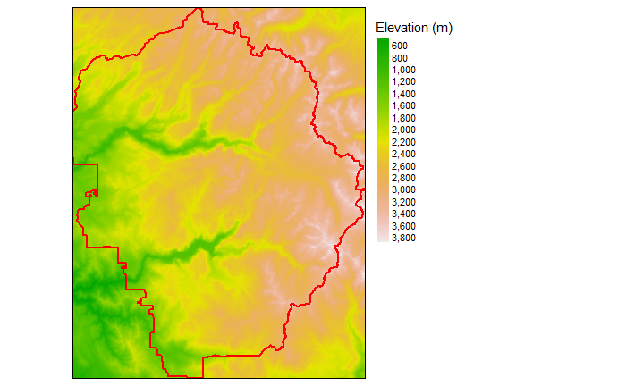

```r
tm_shape(yose_dem_rst_ll) +
  tm_raster(title = "Elevation (m)", style = "cont", n = 15, palette = terrain.colors(256)) +
tm_shape(yose_bnd_ll) +
  tm_borders(col = "red", lwd = 2) +
tm_legend(outside = TRUE)
```

Lastly, we need to project the park DEM into UTM using `projectRaster()` with the following arguments:

- `from`: the raster we want to project
- `to`: omitted in this case (because we’re supplying `crs` and `res`)
- `crs`: pass a proj4 string
- `res`: resolution in map units (which in the case of UTM is meters)
- `method`: choose ‘blinear’ but the cell values (elevation MSL) are continuous, and we want the interpolated values to also be continuous

```r
## Define the proj4 string for UTM 11N
utm11n_wgs84_proj4 <- "+init=epsg:32611"

yose_dem_rst_utm <- projectRaster(from = yose_dem_rst_ll,
                              crs = CRS(utm11n_wgs84_proj4),
                              res = 90,
                              method = "bilinear")
yose_dem_rst_utm
```

```
class      : RasterLayer
dimensions : 880, 708, 623040  (nrow, ncol, ncell)
resolution : 90, 90  (x, y)
extent     : 244387.5, 308107.5, 4151576, 4230776  (xmin, xmax, ymin, ymax)
crs        : +proj=utm +zone=11 +datum=WGS84 +units=m +no_defs
source     : memory
names      : srtm_13_05
values     : 440.8224, 3958.44  (min, max)
```

Plot to make sure it worked:

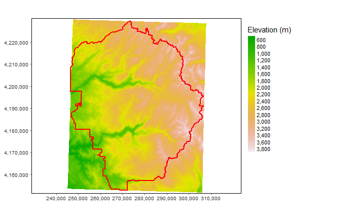

```r
tm_shape(yose_dem_rst_utm) +
  tm_raster(title = "Elevation (m)", style = "cont", n = 15, palette = terrain.colors(256)) +
tm_shape(yose_bnd_utm) +
  tm_borders(col = "red", lwd = 2) +
tm_grid(lines = FALSE) +
tm_layout(legend.outside = TRUE,
          asp = 1.2)
```

## Compute Slope

Slope is one of the criteria for our campsite. We can compute the slope from the DEM using the `raster::terrain()`:

```r
yose_slope_rst <- raster::terrain(yose_dem_rst_utm, opt="slope")
yose_slope_rst
```

```
class      : RasterLayer
dimensions : 880, 708, 623040  (nrow, ncol, ncell)
resolution : 90, 90  (x, y)
extent     : 244387.5, 308107.5, 4151576, 4230776  (xmin, xmax, ymin, ymax)
crs        : +proj=utm +zone=11 +datum=WGS84 +units=m +no_defs
source     : memory
names      : slope
values     : 0, 1.242767  (min, max)
```

Plot to make sure it worked. Note that slope is measured in [radians](https://en.wikipedia.org/wiki/Radian).

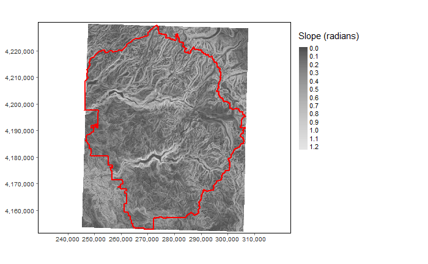

```r
tm_shape(yose_slope_rst) +
  tm_raster(title = "Slope (radians)", style = "cont", n = 15, palette = gray.colors(256)) +
tm_shape(yose_bnd_utm) +
  tm_borders(col = "red", lwd = 2) +
tm_grid(lines = FALSE) +
tm_layout(legend.outside = TRUE,
          asp = 1.2)
```

## Create a Binary Mask for Slope

We create a binary mask of the pixels whose slope < 10%.

```r
## To convert the percent slope to an angle, we use arctan (which returns radians)
max_slope_rad <- atan(0.1)

## Create the TRUE / FALSE mask with a raster algebra expression
yose_lowslope_msk_rst <- (yose_slope_rst <= max_slope_rad)
yose_lowslope_msk_rst
```

```
class      : RasterLayer
dimensions : 880, 708, 623040  (nrow, ncol, ncell)
resolution : 90, 90  (x, y)
extent     : 244387.5, 308107.5, 4151576, 4230776  (xmin, xmax, ymin, ymax)
crs        : +proj=utm +zone=11 +datum=WGS84 +units=m +no_defs
source     : memory
names      : layer
values     : 0, 1  (min, max)
```

Plot to make sure it worked:

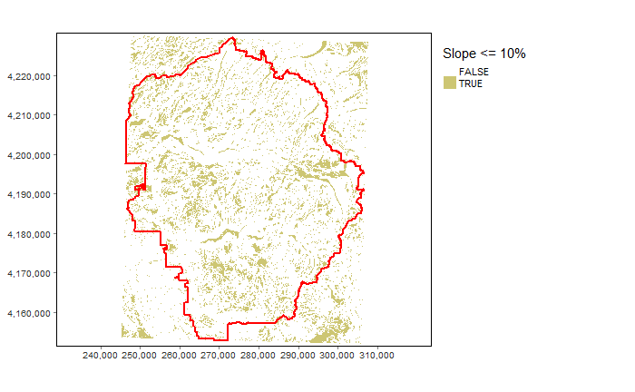

```r
tm_shape(yose_lowslope_msk_rst) +
  tm_raster(title = "Slope <= 10%", style = "fixed", n = 2, palette = c(NA, "khaki3")) +
tm_shape(yose_bnd_utm) +
  tm_borders(col = "red", lwd = 2) +
tm_grid(lines = FALSE) +
tm_layout(legend.outside = TRUE,
          asp = 1.2)
```

## Compute the Distance to Trails Surface

We’ll compute the distance to trails surface (also known as a proximity surface) using `raster::distance()`.

The `distance()` function requires a raster where most cells have NA values, and those that have a feature we want to compute distance to (i.e., the trails) contain ‘1’ values.

Hence the first step is to convert the trails layer into a raster. We could do this with `raster::rasterize()`, but its very slow. Instead we’ll use `stars::st_rasterize()`. In addition to the vector layer, we need to also pass a raster that will be used as the ‘template’ (i.e., origin, # rows and columns, pixel size) for the output.

```r
## Load stars
library(stars)
## Rasterize the trails as a stars object
yose_trails_stars <- stars::st_rasterize(sf = yose_trails_utm %>% transmute(field = 1),
                          template = stars::st_as_stars(setValues(yose_dem_rst_utm, NA)))
```

```
no non-missing arguments to min; returning Infno non-missing arguments to max; returning -Inf
```

```r
## Convert the stars object to a raster object
yose_trails_rst_utm <- as(yose_trails_stars, "Raster")

## View results
yose_trails_rst_utm
```

```
class      : RasterLayer
dimensions : 880, 708, 623040  (nrow, ncol, ncell)
resolution : 90, 90  (x, y)
extent     : 244387.5, 308107.5, 4151576, 4230776  (xmin, xmax, ymin, ymax)
crs        : +proj=utm +zone=11 +datum=WGS84 +units=m +no_defs
source     : memory
names      : layer
values     : 1, 1  (min, max)
```

Plot it to make sure it looks right:

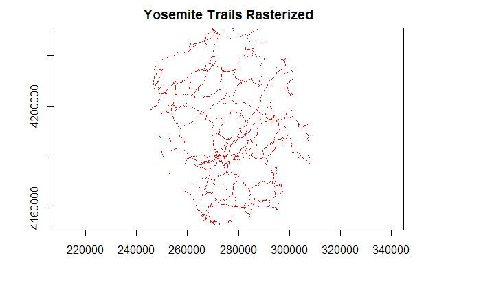

```r
plot(yose_trails_rst_utm, col = "red", legend = FALSE, main = "Yosemite Trails Rasterized")
```

View how many cells have a trail:

```r
freq(yose_trails_rst_utm)
```

```
     value  count
[1,]     1  18510
[2,]    NA 604530
```

Next we compute the distance surface. Note this can take up to a minute.

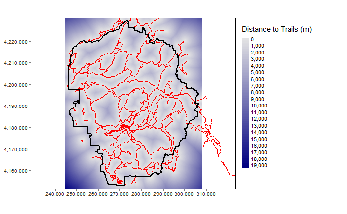

```r
## Compute the distance surface. Note this can take up to a minute.
yose_dist2trails_rst_utm <- raster::distance(yose_trails_rst_utm)

## Plot
tm_shape(yose_dist2trails_rst_utm) +
  tm_raster(title = "Distance to Trails (m)", style = "cont", n = 15,
            palette = colorRampPalette(c("gray90", "navy"))(100)) +
tm_shape(yose_trails_utm) +
  tm_lines(col = "red", lwd = 1) +
tm_shape(yose_bnd_utm) +
  tm_borders(col = "black", lwd = 2) +
tm_grid(lines = FALSE) +
tm_layout(legend.outside = TRUE,
          asp = 1.2)
```

## Create a Binary Mask for Distance to Trails

Our criteria state that the new campsite must be <100 m from an existing trail.

```r
## Create the TRUE / FALSE mask with a raster algebra expression
yose_dist2trails_msk_utm <- (yose_dist2trails_rst_utm <= 100)
yose_dist2trails_msk_utm
```

```
class      : RasterLayer
dimensions : 880, 708, 623040  (nrow, ncol, ncell)
resolution : 90, 90  (x, y)
extent     : 244387.5, 308107.5, 4151576, 4230776  (xmin, xmax, ymin, ymax)
crs        : +proj=utm +zone=11 +datum=WGS84 +units=m +no_defs
source     : memory
names      : layer
values     : 0, 1  (min, max)
```

Plot the distance to trails mask to make sure it worked:

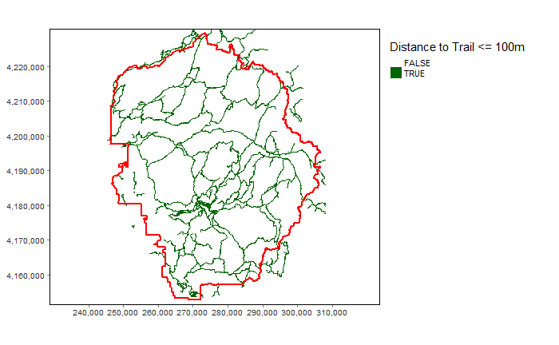

```r
tm_shape(yose_dist2trails_msk_utm) +
  tm_raster(title = "Distance to Trail <= 100m", style = "fixed", n = 2, palette = c(NA, "darkgreen")) +
tm_shape(yose_bnd_utm) +
  tm_borders(col = "red", lwd = 2) +
tm_grid(lines = FALSE) +
tm_layout(legend.outside = TRUE,
          asp = 1.2)
```

## Create the Proximity to Streams Mask

To create a binary mask for the distance to stream criteria, instead of constructing a distance surface as we did for trails, we can simply create a 100m buffer around the streams and rasterize it:

```r
## Create a 100m buffer around the streams
yose_streams_buff_sf_utm <- st_buffer(yose_streams_utm, dist = 100)

## Rasterize the stream biffer, give pixels within the buffer a value of 1, and all other pixels 0
yose_streams_buff_rst_utm <- stars::st_rasterize(sf = yose_streams_buff_sf_utm %>% transmute(field = 1),
                          template = stars::st_as_stars(setValues(yose_dem_rst_utm, 0))) %>%  as(., "Raster")

## View metadata
yose_streams_buff_rst_utm
```

```
class      : RasterLayer
dimensions : 880, 708, 623040  (nrow, ncol, ncell)
resolution : 90, 90  (x, y)
extent     : 244387.5, 308107.5, 4151576, 4230776  (xmin, xmax, ymin, ymax)
crs        : +proj=utm +zone=11 +datum=WGS84 +units=m +no_defs
source     : memory
names      : layer
values     : 0, 1  (min, max)
```

Plot the stream buffer mask to make sure it worked:

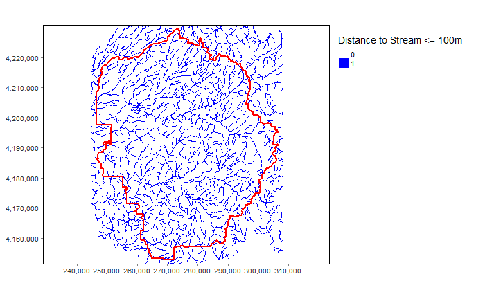

```r
tm_shape(yose_streams_buff_rst_utm) +
  tm_raster(title = "Distance to Stream <= 100m", style = "cat", palette = c(NA, "blue")) +
tm_shape(yose_bnd_utm) +
  tm_borders(col = "red", lwd = 2) +
tm_grid(lines = FALSE) +
tm_layout(legend.outside = TRUE,
          asp = 1.2)
```

## Combine Masks

The last step is to multiply our three masks together using raster algebra. The result will be a raster where cells where all three criteria are met are 1, and everywhere else is 0.

```r
campsite_ok_rst <- yose_dist2trails_msk_utm * yose_lowslope_msk_rst * yose_streams_buff_rst_utm
campsite_ok_rst
```

```
class      : RasterLayer
dimensions : 880, 708, 623040  (nrow, ncol, ncell)
resolution : 90, 90  (x, y)
extent     : 244387.5, 308107.5, 4151576, 4230776  (xmin, xmax, ymin, ymax)
crs        : +proj=utm +zone=11 +datum=WGS84 +units=m +no_defs
source     : memory
names      : layer
values     : 0, 1  (min, max)
```

Plot the combined masks to make sure it worked:

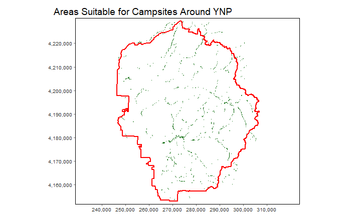

```r
tm_shape(campsite_ok_rst) +
  tm_raster(style = "cat", palette = c(NA, "darkgreen")) +
tm_shape(yose_bnd_utm) +
  tm_borders(col = "red", lwd = 2) +
tm_grid(lines = FALSE) +
tm_layout(legend.show = FALSE,
          main.title = "Areas Suitable for Campsites Around YNP",
          main.title.size = 1.2,
          asp = 1.2)
```

## Crop and Mask the Results to the Park Boundary

We can’t build campsites outside the park, so our last task is to crop and mask the results to the park boundary. Actually we don’t have to crop, we did that when we cropped the SRTM tile above.

```r
campsite_ok_msk_rst <- raster::mask(campsite_ok_rst, yose_bnd_utm)
campsite_ok_msk_rst
```

```
class      : RasterLayer
dimensions : 880, 708, 623040  (nrow, ncol, ncell)
resolution : 90, 90  (x, y)
extent     : 244387.5, 308107.5, 4151576, 4230776  (xmin, xmax, ymin, ymax)
crs        : +proj=utm +zone=11 +datum=WGS84 +units=m +no_defs
source     : memory
names      : layer
values     : 0, 1  (min, max)
```

Plot it to make sure it worked:

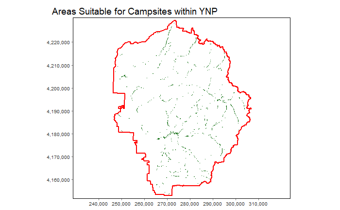

```r
tm_shape(campsite_ok_msk_rst) +
  tm_raster(style = "cat", palette = c(NA, "darkgreen")) +
tm_shape(yose_bnd_utm) +
  tm_borders(col = "red", lwd = 2) +
tm_grid(lines = FALSE) +
tm_layout(legend.show = FALSE,
          main.title = "Areas Suitable for Campsites within YNP",
          main.title.size = 1.2,
          asp = 1.2)
```

## CHALLENGE: Compute the total area

What is the total area suitable for campsites? [Answer](https://bit.ly/3wyqJsa)

```r
# Your answer here
```

## CHALLENGE: Add an Additional Criteria

Add one more criteria - exclude areas within 100m of an existing campsite. Hint: campsites are included in the `yose_poi.shp` layer. [Answer](https://bit.ly/2OnnFxA)

```r
# Your answer here
```

## End

Congratulations, you completed another R Notebook.

Save your Notebook to generate a HTML preview of the code you ran.